# Red de Señalización

Fer Rendón

23/03/2022

#### **Representación verbal**

*Elabora una representación verbal de la red.*

No estoy segura de haber entendido bien la instrucción pero…

El Ca es el regulador de la red, y esta red se mantiene dinámica, ya que al activarse el Ca, solo cuenta con un inhibidor, la CaATPasa, el cual es igualmente activado por Ca. De no ser inhibido, el Ca activa a muchas otras proteínas que tienen entre una y dos conexiones con otras dos proteínas a las que generalmente activan. Por ejemplo, en la parte de arriba es una cascada que activa a dos proteínas (NOS y PLC) y estás a su vez activas otra(s) proteínas que finalmente llegan a activar a CIS, y CIS vuelve a activar al Ca. En la parte de abajo se llega a un “closure”, mediante inhibiciones y activaciones de las proterínas, pero, nuevamente, solo la CaATPasa es capaz de detener todo el ciclo regulado por el Ca.

#### **Reglas**

*Elabora una tabla de posibles reglas de la red.*

Para CIS: cGMP OR cADPR OR InsP3.

| cGMP | cADPR | InsP3 | Condición |
| --- | --- | --- | --- |
| F | F | F | F |
| T | F | F | T |
| F | T | F | T |
| F | F | T | T |
| F | T | T | T |
| T | F | T | T |
| T | T | F | T |
| T | T | T | T |

Para cGMP: GC

| GC | Condición |
| --- | --- |
| F | F |
| T | T |

Para cADPR: ADPRc

| ADPR | Condición |
| --- | --- |
| F | F |
| T | T |

Para InsP3: PLC

| PLC | Condición |
| --- | --- |
| F | F |
| T | T |

Para GC: NO

| NO | Condición |
| --- | --- |
| F | F |
| T | T |

Para ADPRc: NO

| NO | Condición |
| --- | --- |
| F | F |
| T | T |

Para PLC: Ca

| Ca | Condición |
| --- | --- |
| F | F |
| T | T |

Para NO: NOS

| NOS | Condición |
| --- | --- |
| F | F |
| T | T |

Para NOS: Ca

| Ca | Condición |
| --- | --- |
| F | F |
| T | T |

Para Ca: CIS OR CalM AND NOT CaATPase

[output not shown]

Para CaATPase: Ca

| Ca | Condición |
| --- | --- |
| F | F |
| T | T |

Para CalM: NOT Depolar

| Depolar | Condición |
| --- | --- |
| F | V |
| V | F |

Para KEV: Ca

| Ca | Condición |
| --- | --- |
| F | F |
| T | T |

Para HATPase: NOT Ca

| Ca | Condición |
| --- | --- |
| F | T |
| T | F |

Para AnionEM: Ca

| Ca | Condición |
| --- | --- |
| F | F |
| T | T |

Para Closure: AnionEM OR KOUT OR KAP

| AnionEM | KOUT | KAP | Condición |
| --- | --- | --- | --- |
| F | F | F | F |
| F | F | T | T |
| F | T | F | T |
| T | F | F | T |
| F | T | T | T |
| T | T | F | T |
| T | F | T | T |
| T | T | T | T |

Para KOUT: Depolar

| Depolar | Condición |
| --- | --- |
| F | F |
| T | T |

Para KAP: Depolar

| Depolar | Condición |
| --- | --- |
| F | F |
| T | T |

Para Depolar: KEV OR Ca OR AnionEM AND NOT HATPase AND NOT KOUT

| KEV | Ca | AnionEM | HATPase | KOUT | Condición |
| --- | --- | --- | --- | --- | --- |
| F | F | F | F | F | F |
| F | F | F | F | T | F |
| F | F | F | T | F | F |
| F | F | T | F | F | T |
| F | T | F | F | F | T |
| T | F | F | F | F | T |
| F | F | F | T | T | F |
| F | F | T | F | T | F |
| F | T | F | F | T | F |
| T | F | F | F | T | F |
| F | F | T | T | F | F |
| F | T | F | T | F | F |
| T | F | F | T | F | F |
| F | T | T | F | F | T |
| T | F | T | F | F | T |
| T | T | F | F | F | T |
| F | F | T | T | T | F |
| F | T | F | T | T | F |
| F | T | T | F | T | F |
| F | T | T | T | F | F |
| T | F | F | T | T | F |
| T | F | T | F | T | F |
| T | F | T | T | F | F |
| F | T | T | T | T | F |
| T | F | T | T | T | F |
| T | T | F | T | T | F |
| T | T | T | F | T | F |
| T | T | T | T | F | F |
| T | T | T | T | T | F |

Eso estuvo mortal. Espero sean todos los estados posibles jaja.

#### **Atractores**

*Encuentra y discute biológicamente el significado de los atractores (Usa BoolNet).*

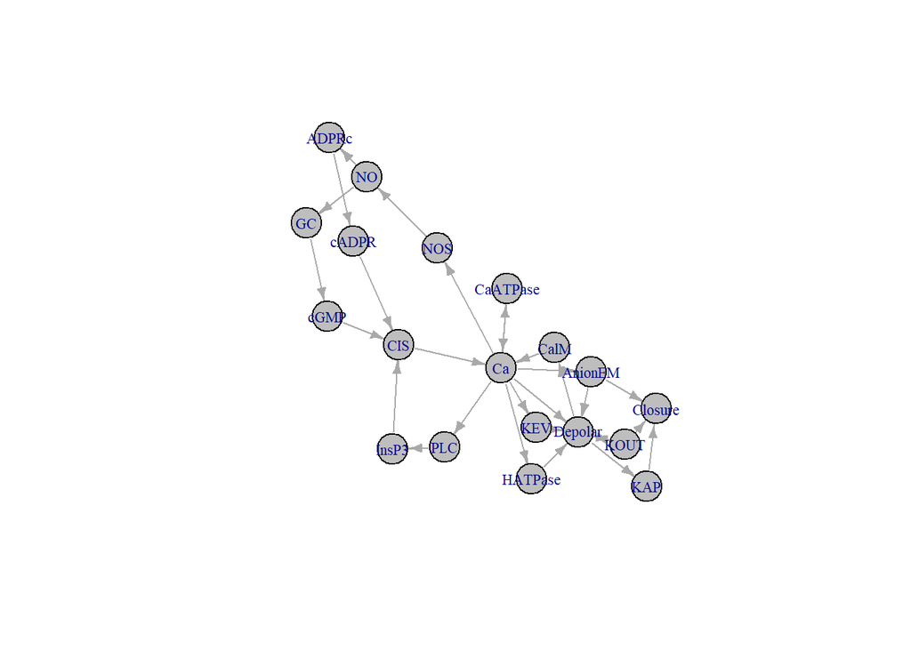

```r
library (BoolNet)

# A partir del archivo "regulation.txt" creado en base a las reglas antes mencionadas:

regulation <- loadNetwork ("regulation.txt")

# La red se aprecia con:
plotNetworkWiring (regulation)
```

```r
# Los atractores se obtienen con:
attractors <- getAttractors (regulation)
attractors
```

```
## Attractor 1 is a simple attractor consisting of 1 state(s) and has a basin of 512812 state(s):
##
##  |--<------------------|
##  V                     |
##  1111111111101011111   |
##  V                     |
##  |-->------------------|
##
##
## Genes are encoded in the following order: CIS cGMP cADPR InsP3 GC ADPRc PLC NO NOS Ca CaATPase CalM KEV HATPase AnionEM Closure KOUT KAP Depolar
##
## Attractor 2 is a simple attractor consisting of 2 state(s) and has a basin of 11476 state(s):
##
##  |--<------------------|
##  V                     |
##  0111000101000101111   |
##  1000111010101011111   |
##  V                     |
##  |-->------------------|
##
##
## Genes are encoded in the following order: CIS cGMP cADPR InsP3 GC ADPRc PLC NO NOS Ca CaATPase CalM KEV HATPase AnionEM Closure KOUT KAP Depolar
```

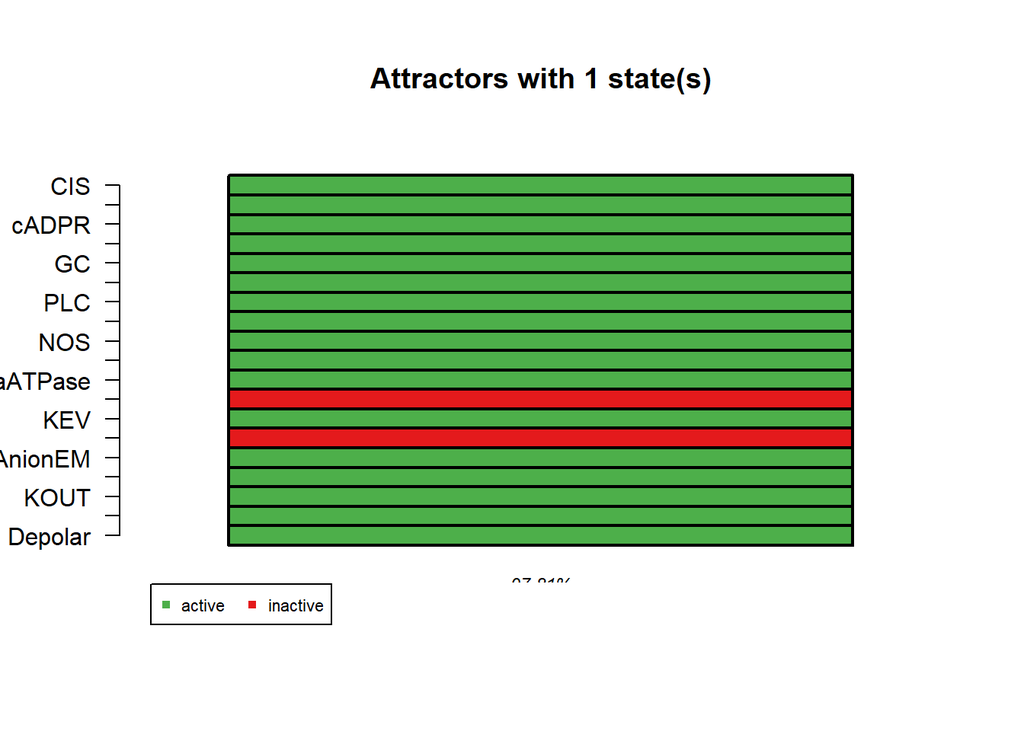

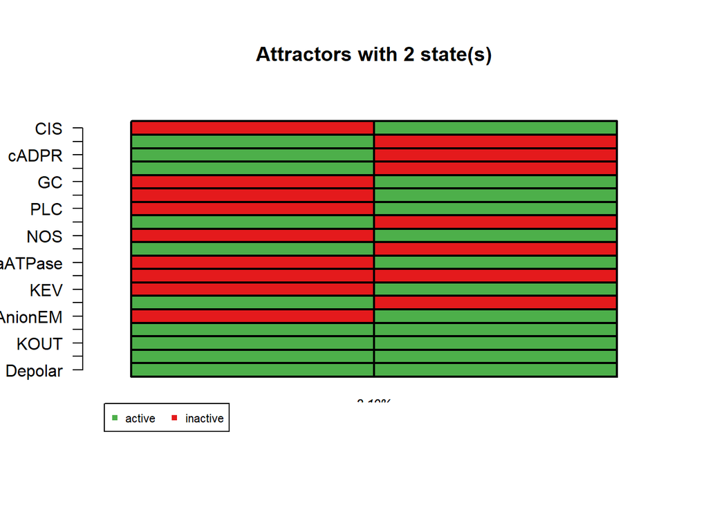

```
## $`1`
##          Attr1.1
## CIS            1
## cGMP           1
## cADPR          1
## InsP3          1
## GC             1
## ADPRc          1
## PLC            1
## NO             1
## NOS            1
## Ca             1
## CaATPase       1
## CalM           0
## KEV            1
## HATPase        0
## AnionEM        1
## Closure        1
## KOUT           1
## KAP            1
## Depolar        1
##
## $`2`
##          Attr2.1 Attr2.2
## CIS            0       1
## cGMP           1       0
## cADPR          1       0
## InsP3          1       0
## GC             0       1
## ADPRc          0       1
## PLC            0       1
## NO             1       0
## NOS            0       1
## Ca             1       0
## CaATPase       0       1
## CalM           0       0
## KEV            0       1
## HATPase        1       0
## AnionEM        0       1
## Closure        1       1
## KOUT           1       1
## KAP            1       1
## Depolar        1       1
```